# Academic Alerts Analysis

Fall 2025, Harpur College, Binghamton University

## Alerts in Harpur

This analysis examines data from all 9,282 Harpur College students and their 35,822 Fall 2025 class enrollments; it focuses on the use and impact of the academic alert system.

**An important distinction.** The alert system has two very different types of alerts:

- **Medium and High alerts** I call **“warning alerts”**: low exam scores, missed assignments, attendance problems, danger of failing. These are the alerts that matter for intervention, and they are the focus of this analysis throughout.
- **Kudos** (low alerts) are **not warnings**. These are positive feedback — no requests for intervention. As shown below, students receiving only kudos look similar to non-alerted students. **Unless otherwise noted, when this analysis refers to “alerts,” it means warning alerts (medium/high).**

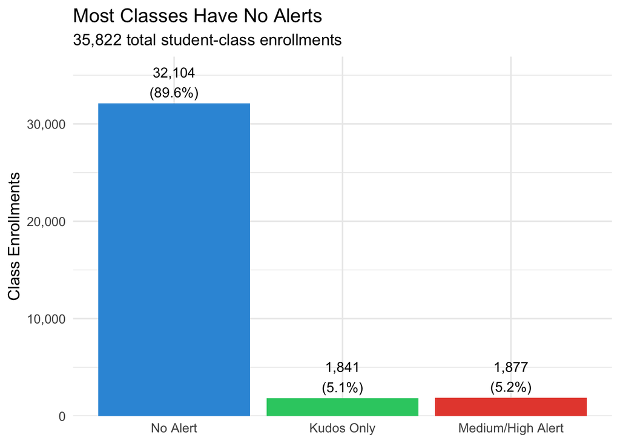

## Who Gets Alerts?

### Alerts Track Cumulative GPA

Students who receive warning alerts already have substantially lower GPAs. Kudos-only students — those receiving positive feedback — look nearly identical to students with no alerts.

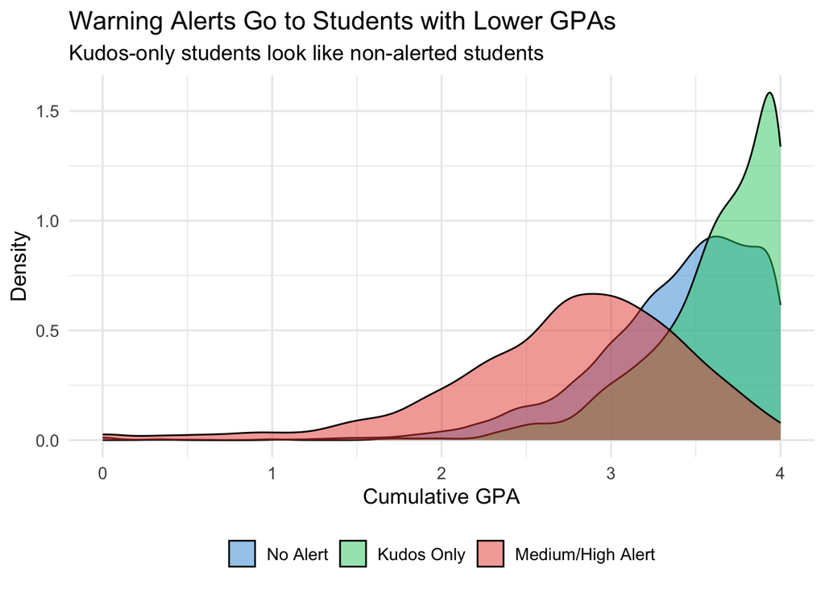

| Alert Category | Students | Mean GPA | Median GPA | % Below 2.5 |
| --- | --- | --- | --- | --- |
| No Alert | 6,347 | 3.38 | 3.48 | 5.9% |
| Kudos Only | 1,418 | 3.61 | 3.71 | 1.8% |
| Medium/High Alert | 1,517 | 2.75 | 2.84 | 29.8% |

### Alerts and Academic Standing

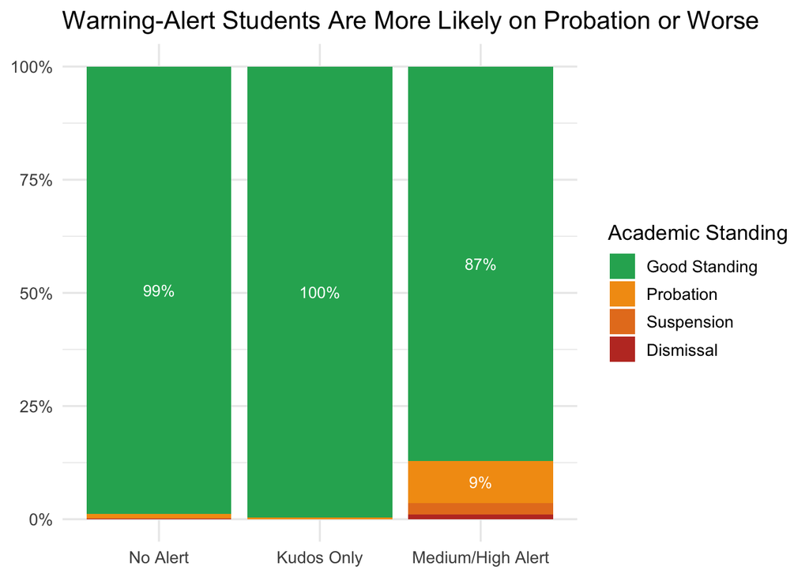

### EOP Students

EOP students receive alerts — especially warning alerts — at higher rates

| EOP | N | Any Alert | Warning Alert | Alert Rate | Warning Rate |
| --- | --- | --- | --- | --- | --- |
| Non-EOP | 8803 | 2708 | 1325 | 30.8% | 15.1% |
| EOP | 479 | 227 | 192 | 47.4% | 40.1% |

## Who Issues Alerts?

Alert system usage is highly concentrated. A small number of departments and instructors generate the majority of alerts.

### Departments

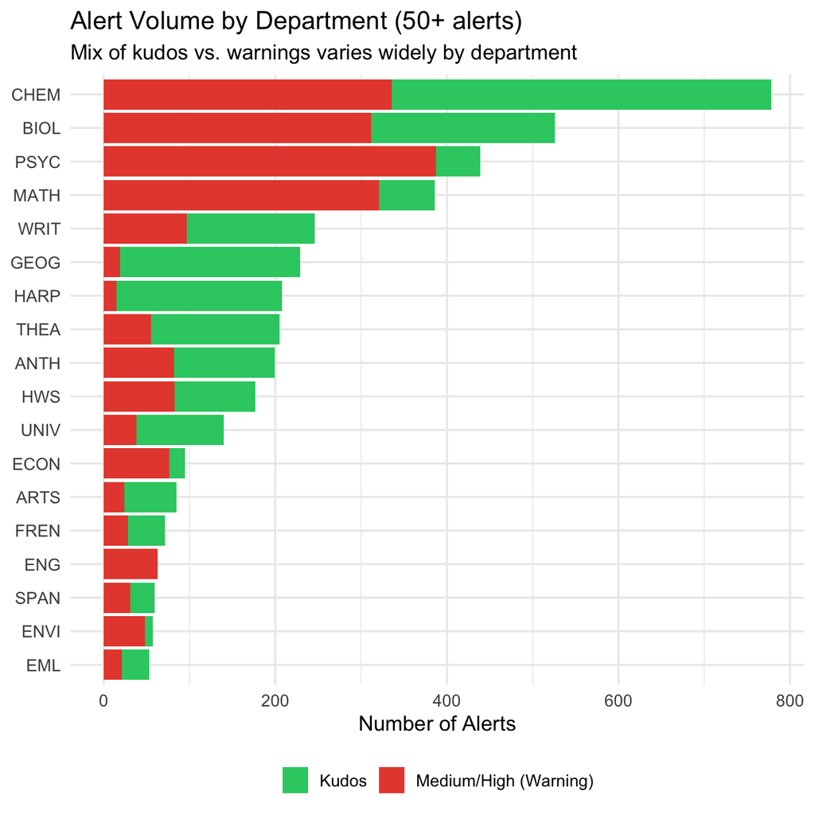

### Kudos vs. Warnings: Who Issues What?

Most alert-issuing instructors send only warnings, not kudos

| Instructor Type | N Instructors | Percent |
| --- | --- | --- |
| Both | 75 | 27.1% |
| Kudos only | 13 | 4.7% |
| Warnings only | 189 | 68.2% |

Of the 277 instructors who issue any alert, **264** issue warnings while only **88** issue kudos. Kudos account for 45.1% of all alerts (1,851 of 4,103), but they are heavily concentrated:

Top 10 kudos issuers — these instructors account for the bulk of all kudos

| Instructor | Kudos | Warnings | Total |
| --- | --- | --- | --- |
| Benjamin Williamson | 225 | 88 | 313 |
| Erin Potter | 163 | 7 | 170 |
| Michael Armstrong | 124 | 113 | 237 |
| Michel Shamoon Pour | 99 | 5 | 104 |
| Rebecca Kissling | 99 | 70 | 169 |
| Shane McCarty | 64 | 0 | 64 |
| Christina Baer | 62 | 10 | 72 |
| Deborah Kreiss | 59 | 0 | 59 |
| Steven Murphy | 41 | 26 | 67 |
| Wan Yu | 40 | 0 | 40 |

### Instructor Concentration (Warning Alerts)

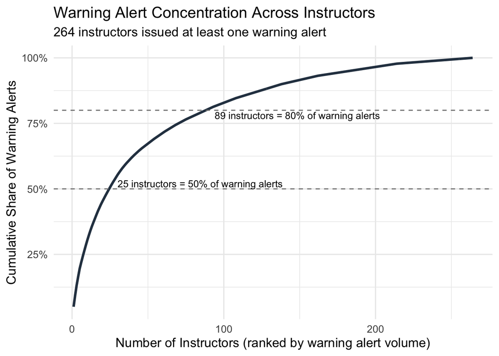

Among the 264 instructors who issued at least one warning alert, a small group accounts for the bulk of the system’s output. But this concentration tells only part of the story.

### Alert Coverage: Instructors vs. Students

Alert system coverage: few instructors, but many students

| Metric | Count | Percent |
| --- | --- | --- |
| Instructors who issue alerts | 277 / 721 | 38.4% |
| Course sections with at least 1 alert | 403 / 1835 | 22.0% |
| Students in at least 1 alert-issuing class | 7,884 / 9,282 | 84.9% |

Only 38.4% of instructors issue alerts, and they teach only 22.0% of course sections. But because alert-issuing instructors tend to teach **large classes**, 84.9% of all students are enrolled in at least one class where alerts are used. **The system’s *student-level* reach is much broader than its instructor-level adoption suggests.**

## Alerts and Student Outcomes

The descriptive analysis above suggests alerts correctly identify struggling students in terms of standing and lower gpas. What are student outcomes given alerts or their absence?

### Raw Outcomes: Warned Students Do Worse

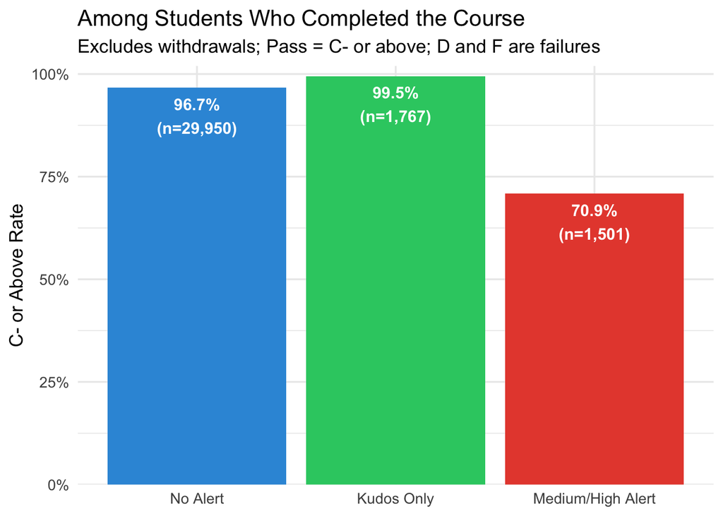

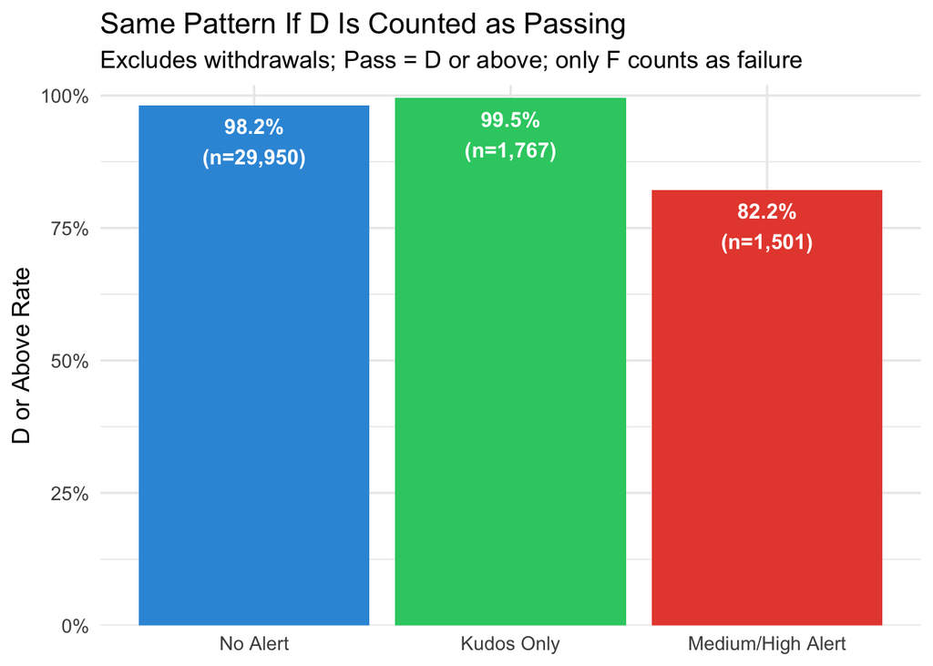

### Grade Distribution

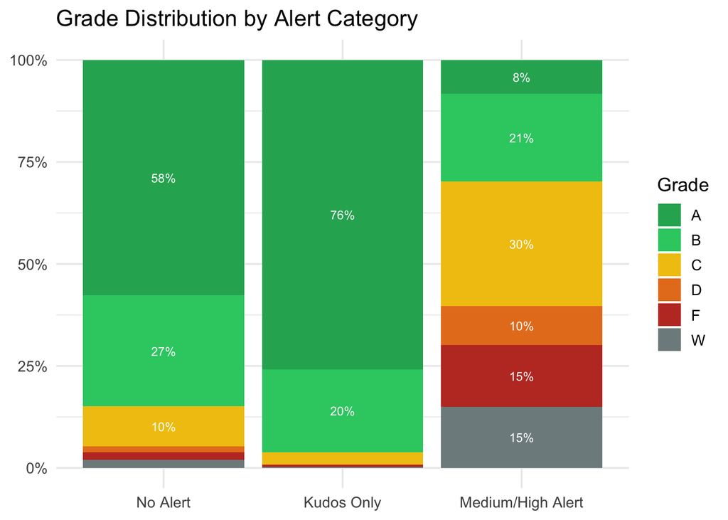

### More Alerts, Worse Outcomes

More alerts for a single student should produce greater intervention effort. The grade outcomes for students with multiple alerts are not great, and seem to get worse as the number of alerts grows. Of course, this isn’t because of the alerts - the alerts are symptomatic of how much trouble the student is in. How much intervention is changing outcomes we cannot say, but students with more alerts pass considerably less frequently. Again, this may suggest alerts correctly identify students in need of help, but that help is difficult to provide.

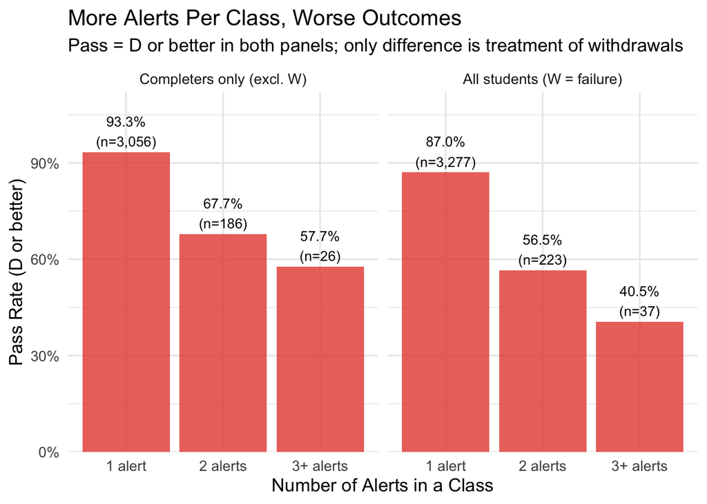

In this plot, pass indicates a grade of D or better; it excludes withdrawals. The pattern is similar if withdrawals are included as failures.

### Same Student, Different Classes

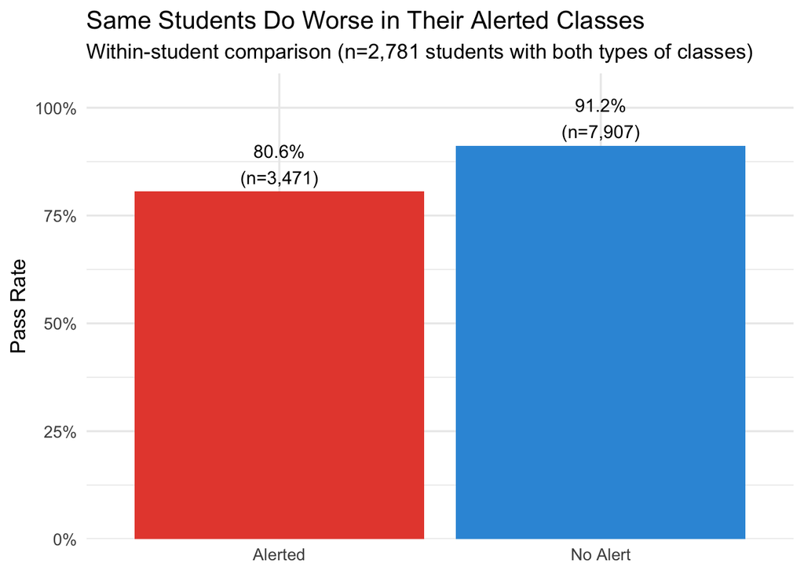

[figure not shown]

This is not surprising: warning alerts are issued *because* students are struggling in a particular class. But it means the alert system identifies problems rather than solving them.

### What Warning Alerts Miss

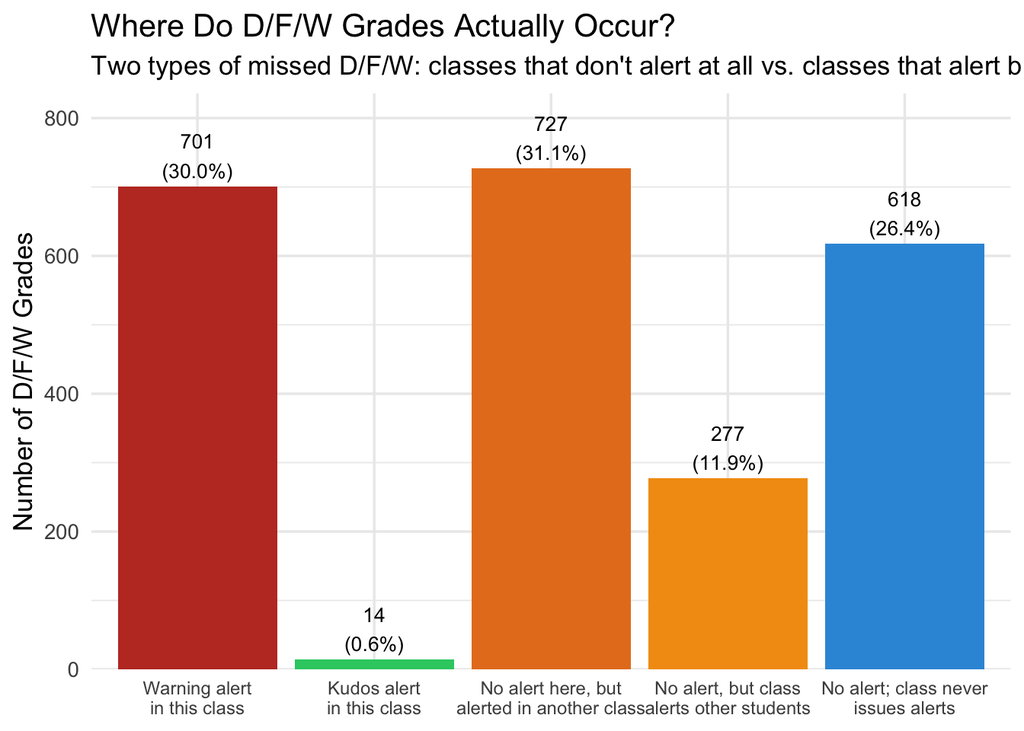

Among D/F/W grades where the student had no alert in that class and was never alerted anywhere:

- **26.4%** occur in classes that never issue alerts at all — there is no measurement effort, so struggling students are invisible to the system.
- **11.9%** occur in classes that *do* alert other students but missed these individuals — a measurement problem where the instructor couldn’t (or didn’t) identify these students as struggling despite flagging others in the same class.

### Which Courses Have Unalerted D/F/W Grades?

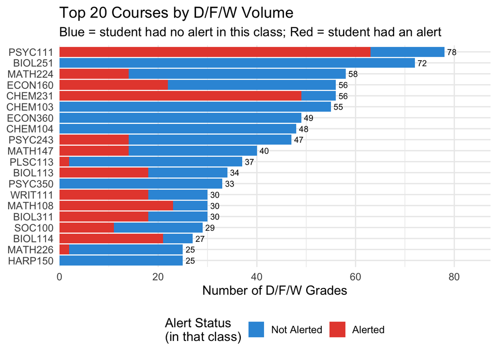

Some courses have many D/F/W grades with *zero* alerts issued. Others have strong alert coverage. The pattern varies widely by course and instructor.

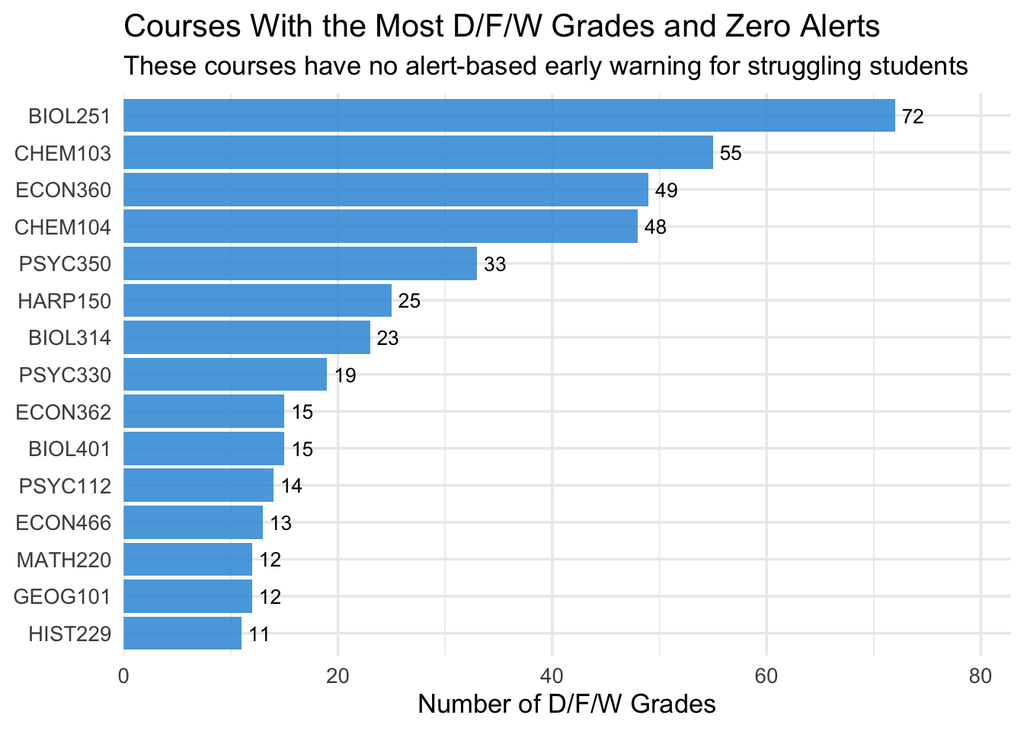

Among the 54 courses with 10 or more D/F/W grades, **16 have zero alerts**—accounting for 427 D/F/W grades (31.0% of D/F/W grades in high-volume courses). Even in courses that do use alerts, many struggling students go unidentified.

#### Instructors Who Alert but Still Miss Many D/F/W Students

Instructor/course combinations that issue warning alerts but still have 5+ unwarned D/F/W students

| Course | Instructor | D/F (Warned) | W (Warned) | D/F (Not Warned) | W (Not Warned) | Warning Alerts | All Alerts |
| --- | --- | --- | --- | --- | --- | --- | --- |
| MATH147 | Chazal, Marie | 9 | 5 | 17 | 9 | 24 | 24 |
| ECON160 | Sharma, Amarendra | 9 | 5 | 18 | 4 | 19 | 19 |
| ECON162 | Christianson, Kenneth | 5 | 1 | 15 | 3 | 10 | 20 |
| BIOL113 | Marcus, Sarah | 17 | 1 | 13 | 3 | 67 | 67 |
| PHYS121 | Nale, Jonathan | 3 | 0 | 11 | 5 | 22 | 22 |
| HIST103A | Parkinson, Robert | 1 | 0 | 10 | 4 | 1 | 1 |
| BIOL332 | Fiumera, Heather | 0 | 1 | 10 | 2 | 1 | 1 |
| ECON210 | Keskar, Ajinkya | 0 | 3 | 5 | 5 | 4 | 4 |
| PSYC358 | Lim, Sung Joo | 11 | 0 | 9 | 1 | 18 | 18 |
| SOC100 | Jimenez-Munoz, Gladys | 5 | 1 | 6 | 3 | 6 | 6 |
| PSYC361 | Coles, Meredith | 1 | 0 | 7 | 1 | 1 | 1 |
| PLSC117 | Fordham, Benjamin | 1 | 0 | 7 | 0 | 3 | 3 |
| PLSC319 | Licht, Amanda | 1 | 2 | 2 | 5 | 3 | 3 |
| PSYC111 | Vanpetten, Cyma | 25 | 4 | 4 | 3 | 37 | 37 |
| PSYC344 | Conte, Stefania | 5 | 0 | 7 | 0 | 5 | 9 |
| BIOL114 | Armstrong, Michael | 14 | 7 | 5 | 1 | 109 | 230 |
| ECON160 | Wang, Wenya | 5 | 3 | 5 | 1 | 8 | 8 |
| HIST382A | Skopyk, Bradley | 0 | 2 | 4 | 2 | 2 | 2 |
| LING114 | Nielsen, Kristina | 1 | 1 | 4 | 2 | 2 | 2 |
| MATH224 | Dang, Huy | 3 | 0 | 5 | 1 | 8 | 8 |
| MATH226 | Viola, Stefan | 0 | 0 | 2 | 4 | 1 | 1 |
| MATH227 | Koskulitz, Tara | 1 | 0 | 2 | 4 | 2 | 2 |
| PSYC111 | Altman, Meaghan | 8 | 4 | 2 | 4 | 33 | 33 |
| SOC100 | Choudary, Wendie | 2 | 1 | 2 | 4 | 9 | 9 |
| BIOL313 | Miles, Carol | 0 | 2 | 3 | 2 | 2 | 3 |
| CHEM106 | Rich, Christopher | 1 | 4 | 0 | 5 | 28 | 39 |
| COLI110 | Sincox, Bailey | 4 | 0 | 4 | 1 | 6 | 6 |
| HIST103A | Lederman, Leonard | 1 | 0 | 3 | 2 | 1 | 1 |
| MATH226 | Koskulitz, Tara | 1 | 1 | 0 | 5 | 5 | 5 |
| PHIL101 | Burkett, Daniel | 1 | 2 | 3 | 2 | 3 | 3 |
| PSYC223 | Gibb, Brandon | 0 | 1 | 4 | 1 | 3 | 3 |
| PSYC243 | Mastroleo, Nadine | 7 | 7 | 4 | 1 | 18 | 18 |

## What Actually Predicts Outcomes?

### GPA Dominates

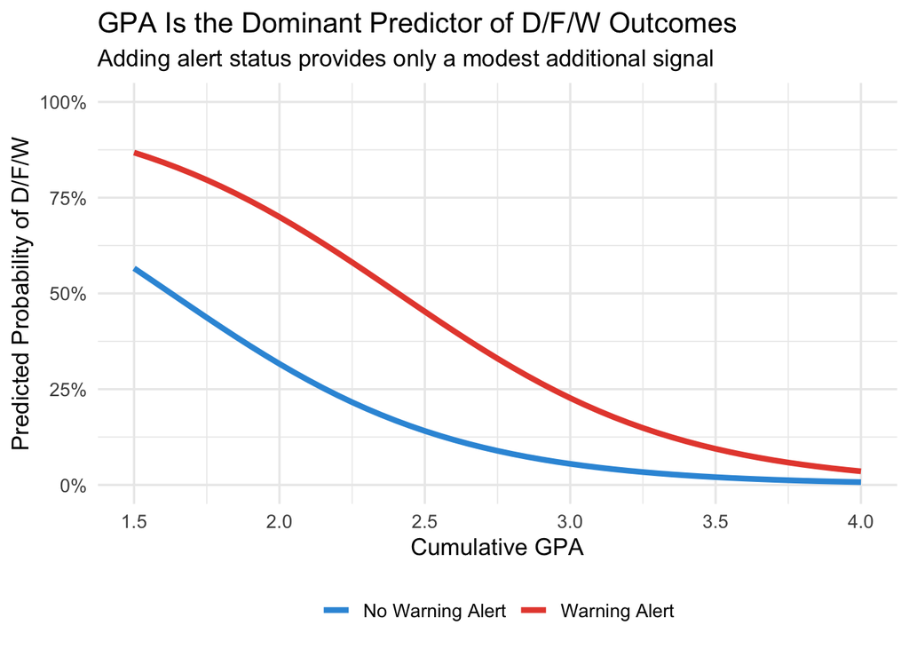

Model comparison: GPA only vs. GPA + Warning Alert, by outcome type

| Outcome | AIC (GPA only) | AIC (GPA + Alert) | R² (GPA only) | R² (GPA + Alert) | R² Improvement |
| --- | --- | --- | --- | --- | --- |
| D/F/W | 12401.9 | 11838.0 | 0.272 | 0.306 | 12.2% |
| D/F only | 7726.5 | 7541.0 | 0.355 | 0.371 | 4.4% |
| W only | 7799.2 | 7483.2 | 0.055 | 0.093 | 70.4% |

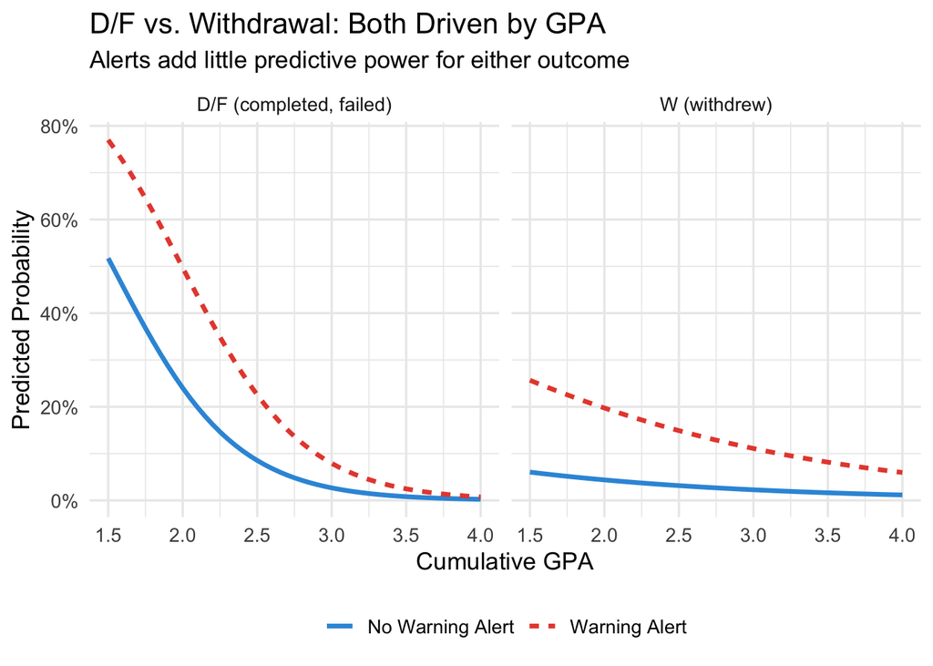

### Predicted Outcomes by GPA and Alert Status

Predicted probabilities by GPA, alert status, and outcome type

| GPA | No Warning Alert: D/F/W | Warning Alert: D/F/W | No Warning Alert: D/F | Warning Alert: D/F | No Warning Alert: W | Warning Alert: W |
| --- | --- | --- | --- | --- | --- | --- |
| 1.5 | 57% | 87% | 52% | 77% | 6% | 26% |
| 2.0 | 32% | 70% | 24% | 50% | 4% | 20% |
| 2.5 | 14% | 45% | 9% | 23% | 3% | 15% |
| 3.0 | 5% | 23% | 3% | 8% | 2% | 11% |
| 3.5 | 2% | 9% | 1% | 2% | 2% | 8% |

## Summary

| Finding | Value |
| --- | --- |
| Warning-alert students: non-D/F/W rate | 60.3% |
| No-alert students: non-D/F/W rate | 94.7% |
| D/F/W grades from never-alerted students | 38.3% |
| Same student: non-D/F/W rate in non-alerted classes | 91.2% |
| Same student: non-D/F/W rate in alerted classes | 80.6% |
| EOP students receiving warning alerts | 40.1% |
| Non-EOP students receiving warning alerts | 15.1% |